# Taller: Lo que las variables comparten

Análisis factorial para la Gerencia de Riesgo de Crédito

Oscar Manuel Contreras Gacha (20221020052)

Juan Pablo Sarmiento Ramírez (20221020138)

Steven Navarro Parrales (20221020048)

Juan Diego Grajales Castillo (20221020128)

Estadística Multidimensional · 26158 · grupo 020-81 · periodo 2026-3

Cada resultado se lee con tres frases:

- 👀 **Qué vemos**: el número o el gráfico, sin interpretar.
- 💼 **Qué significa para el cliente**: la traducción a la cartera de tarjetas.
- ✅ **Qué decide el cliente**: la consecuencia práctica.

Este taller continúa los dos talleres de componentes principales, que a su vez parten de los Módulos 15 a 17 de `Entrega/analisis_synthetic_credit_card.Rmd`. Usamos **las mismas 9 variables** de esos talleres y **la misma transformación** (`log(x+1)` a las de asimetría mayor que 1). La diferencia está en la pregunta: el PCA buscaba **el mejor resumen** de las variables; el análisis factorial busca **lo que las variables comparten** —una «habilidad» común que no se mide directamente— y separa en cada variable la **parte común** (lo que viene de esa habilidad) de la **parte propia** (lo que la variable dice por su cuenta).

# 1 El encargo

```r
ruta <- c("../data/bronze/synthetic_credit_card_customer_behavior_dataset.csv",
          "data/bronze/synthetic_credit_card_customer_behavior_dataset.csv")
ruta <- ruta[file.exists(ruta)][1]
if (is.na(ruta)) stop("No se encuentra el CSV: ajuste la ruta en este bloque.")
credit <- read.csv(ruta, stringsAsFactors = FALSE)

vars <- c("Annual_Income", "Credit_Limit", "Statement_Balance", "Payment_Amount",
          "EMI_Count", "Monthly_Transactions", "Avg_Transaction_Value",
          "International_Transactions", "Credit_Score")
etiqueta <- c(Annual_Income = "Ingreso anual", Credit_Limit = "Cupo",
              Statement_Balance = "Saldo facturado", Payment_Amount = "Monto pagado",
              EMI_Count = "Compras a cuotas", Monthly_Transactions = "Compras al mes",
              Avg_Transaction_Value = "Valor por compra",
              International_Transactions = "Compras internacionales",
              Credit_Score = "Puntaje crediticio")

# Misma transformación de los talleres de PCA: log(x+1) si |asimetría| > 1
skew <- function(x) mean(((x - mean(x)) / sd(x))^3)
con_log <- vars[abs(sapply(credit[vars], skew)) > 1]
X <- credit[vars]
X[con_log] <- lapply(X[con_log], log1p)
colnames(X) <- etiqueta[vars]      # nombres en español para todas las salidas
p <- ncol(X)
R <- cor(X)
```

**El cliente sigue siendo la Gerencia de Riesgo de Crédito del banco emisor** de las 50 000 tarjetas (rupias indias, ₹). Cada mes decide qué clientes entran al programa de seguimiento preventivo. En los talleres de PCA le mostramos que la cartera se resume en dos direcciones: **tamaño** y **riesgo**. Ahora la Gerencia pregunta otra cosa:

> *«Mis analistas dicen que ingreso, cupo, saldo, pagos y número de compras son “lo mismo”: la capacidad económica del cliente. ¿Es cierto que hay una sola capacidad detrás de todas? ¿Y el puntaje crediticio, también es parte de esa capacidad?»*

## 1.1 Las variables que escogimos

Escogemos 9 variables numéricas que creemos que **comparten algo**: el dinero que maneja el cliente (ingreso, cupo, saldo, pago) y cuánto usa la tarjeta (compras al mes, valor por compra, cuotas, compras internacionales). Metemos a propósito el **puntaje crediticio**, que es lo que le importa a la Gerencia, para comprobar si comparte algo con las demás o va solo. 6 entran con logaritmo (Ingreso anual, Cupo, Saldo facturado, Monto pagado, Valor por compra y Compras internacionales); el análisis factorial trabaja sobre la matriz de correlación, así que no hace falta estandarizar a mano.

## 1.2 ¿Comparten lo suficiente? El KMO

El KMO compara las correlaciones entre variables con las correlaciones **parciales** (lo que queda entre dos variables cuando se descuentan todas las demás). Si lo que comparten dos variables también lo comparten con las otras, la parcial es pequeña y el KMO se acerca a 1. Por debajo de 0,5 una variable no comparte lo suficiente con el grupo.

```r
kmo <- KMO(R)
data.frame(variable = names(kmo$MSAi), KMO = round(kmo$MSAi, 2),
           lectura = cut(kmo$MSAi, c(0, 0.5, 0.6, 0.7, 0.8, 0.9, 1),
                         c("inaceptable", "miserable", "mediocre", "aceptable",
                           "meritorio", "maravilloso")),
           row.names = NULL)
```

| variable | KMO | lectura |
| --- | --- | --- |
| Ingreso anual | 0.86 | meritorio |
| Cupo | 0.77 | aceptable |
| Saldo facturado | 0.66 | mediocre |
| Monto pagado | 0.65 | mediocre |
| Compras a cuotas | 0.92 | maravilloso |
| Compras al mes | 0.73 | aceptable |
| Valor por compra | 0.76 | aceptable |
| Compras internacionales | 0.92 | maravilloso |
| Puntaje crediticio | 0.02 | inaceptable |

```r
c(KMO_global = round(kmo$MSA, 2))
```

```
## KMO_global
##       0.71
```

- 👀 **Qué vemos**: el KMO global es 0,71 (aceptable) y todas las variables pasan de 0,6 salvo el puntaje crediticio, con 0,02.
- 💼 **Qué significa para el cliente**: las ocho variables de dinero y uso comparten algo, y el puntaje no comparte casi nada con ellas; lo dejamos para ver si pertenece o no a la «capacidad» de la que hablan los analistas.
- ✅ **Qué decide el cliente**: tiene sentido buscar una habilidad común en la ficha, y el puntaje es el primer candidato a quedar por fuera.

# 2 Una sola habilidad

```r
fa1 <- fa(R, nfactors = 1, fm = "ml", n.obs = nrow(X))
carga1 <- fa1$loadings[, 1]
if (sum(carga1) < 0) carga1 <- -carga1   # el signo es arbitrario: más capacidad = positivo

partes <- data.frame(variable = names(carga1),
                     carga = round(carga1, 3),
                     comun = round(100 * carga1^2, 1),          # parte común, de cada 100
                     propia = round(100 * fa1$uniquenesses, 1),  # parte propia, de cada 100
                     row.names = NULL)
partes <- partes[order(-partes$comun), ]
partes
```

|  | variable | carga | comun | propia |
| --- | --- | --- | --- | --- |
| 2 | Cupo | 0.996 | 99.1 | 0.9 |
| 1 | Ingreso anual | 0.987 | 97.5 | 2.5 |
| 3 | Saldo facturado | 0.946 | 89.6 | 10.4 |
| 4 | Monto pagado | 0.886 | 78.5 | 21.5 |
| 7 | Valor por compra | 0.772 | 59.7 | 40.3 |
| 6 | Compras al mes | 0.676 | 45.7 | 54.3 |
| 5 | Compras a cuotas | 0.666 | 44.3 | 55.7 |
| 8 | Compras internacionales | 0.654 | 42.7 | 57.3 |
| 9 | Puntaje crediticio | 0.018 | 0.0 | 100.0 |

La **carga** es la correlación de cada variable con la habilidad común. Su cuadrado es la **parte común**: de cada 100 partes de las diferencias entre clientes en esa variable, cuántas vienen de la habilidad. Lo que falta para llegar a 100 es la **parte propia**.

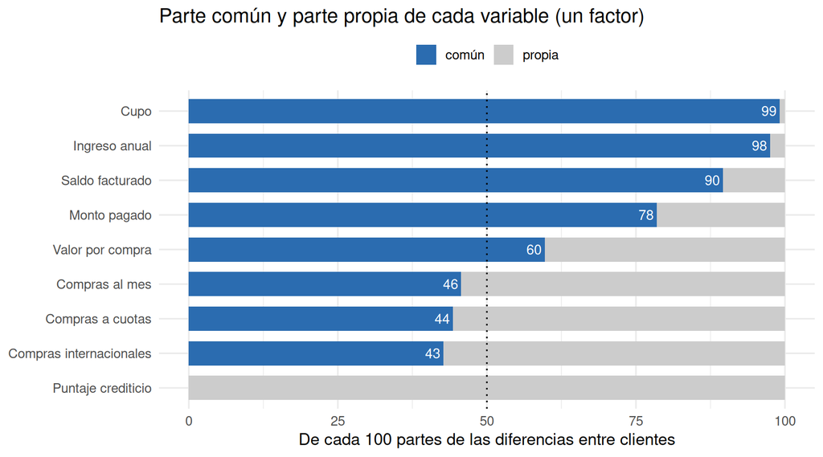

```r
largo <- rbind(data.frame(variable = partes$variable, parte = "común", valor = partes$comun),
               data.frame(variable = partes$variable, parte = "propia", valor = partes$propia))
largo$variable <- factor(largo$variable, levels = rev(partes$variable))
largo$parte <- factor(largo$parte, levels = c("propia", "común"))

ggplot(largo, aes(valor, variable, fill = parte)) +
  geom_col(width = 0.7) +
  geom_text(data = subset(largo, parte == "común" & valor > 8),
            aes(label = coma(valor, 0)), hjust = 1.2, colour = "white", size = 3.8) +
  scale_fill_manual(values = c("común" = "#2B6CB0", "propia" = "grey80"),
                    breaks = c("común", "propia")) +
  geom_vline(xintercept = 50, linetype = 3) +
  labs(x = "De cada 100 partes de las diferencias entre clientes", y = NULL, fill = NULL,
       title = "Parte común y parte propia de cada variable (un factor)") +
  theme(legend.position = "top")
```

- 👀 **Qué vemos**: la habilidad común explica casi todo del cupo (99 de cada 100) y del ingreso (98), buena parte del saldo y del pago, y entre 43 y 60 de cada 100 de las de uso; en total reúne 61,9 de cada 100 partes de la ficha.
- 💼 **Qué significa para el cliente**: llamamos a esa habilidad **capacidad económica** (un nombre nuestro, leído de las cargas), y los analistas tienen razón para el dinero, porque ingreso y cupo son casi pura capacidad, pero solo a medias para el uso, donde más de la mitad de lo que mueve cada variable es otra cosa.
- ✅ **Qué decide el cliente**: para medir capacidad le bastan ingreso y cupo, y las variables de uso conviene mirarlas aparte.

## 2.1 ¿Qué variable es casi toda propia?

```r
mas_propia <- partes$variable[which.max(partes$propia)]
partes[partes$variable == mas_propia, ]
```

|  | variable | carga | comun | propia |
| --- | --- | --- | --- | --- |
| 9 | Puntaje crediticio | 0.018 | 0 | 100 |

- 👀 **Qué vemos**: el **puntaje crediticio** es 100,0 de cada 100 propio (carga 0,018), el mismo resultado del KMO medido de otra forma.
- 💼 **Qué significa para el cliente**: **el riesgo no es parte de la capacidad económica**, porque saber cuánto gana, cuánto cupo tiene o cuánto compra un cliente no dice nada de su puntaje; no sabemos si esa parte propia es error de medición, pero el informe de entrega muestra que el puntaje se mueve con la proporción pagada y el uso del cupo.
- ✅ **Qué decide el cliente**: no puede usar la capacidad, ni el tipo de tarjeta (que se asigna por ingreso), como sustituto del riesgo, y el puntaje debe entrar **por su cuenta** a la decisión de seguimiento.

## 2.2 ¿Alcanza una habilidad?

Si una sola habilidad explica lo que comparten las variables, la correlación entre dos variables debe ser **el producto de sus cargas**: $r_{ij} \approx \ell_i \, \ell_j$. Las dos variables se parecen solo porque las dos se parecen a la habilidad. Lo comprobamos para los 36 pares.

```r
pares <- which(upper.tri(R), arr.ind = TRUE)
comparacion <- data.frame(var_1 = rownames(R)[pares[, 1]],
                          var_2 = colnames(R)[pares[, 2]],
                          correlacion = R[pares],
                          producto_cargas = carga1[pares[, 1]] * carga1[pares[, 2]])
comparacion$diferencia <- comparacion$correlacion - comparacion$producto_cargas
comparacion <- comparacion[order(-abs(comparacion$diferencia)), ]
rownames(comparacion) <- NULL

c(pares = nrow(comparacion),
  diferencia_menor_a_0.05 = sum(abs(comparacion$diferencia) < 0.05),
  diferencia_mayor_a_0.1 = sum(abs(comparacion$diferencia) > 0.1))
```

```
##                   pares diferencia_menor_a_0.05  diferencia_mayor_a_0.1
##                      36                      31                       3
```

```r
transform(head(comparacion, 6), correlacion = round(correlacion, 3),
          producto_cargas = round(producto_cargas, 3), diferencia = round(diferencia, 3))
```

|  | var_1 | var_2 | correlacion | producto_cargas | diferencia |
| --- | --- | --- | --- | --- | --- |
| 1 | Compras al mes | Valor por compra | 0.201 | 0.522 | -0.321 |
| 2 | Saldo facturado | Puntaje crediticio | -0.169 | 0.017 | -0.186 |
| 3 | Compras a cuotas | Compras al mes | 0.565 | 0.450 | 0.116 |
| 4 | Saldo facturado | Monto pagado | 0.933 | 0.839 | 0.095 |
| 5 | Monto pagado | Puntaje crediticio | 0.108 | 0.016 | 0.093 |
| 6 | Compras a cuotas | Puntaje crediticio | -0.028 | 0.012 | -0.040 |

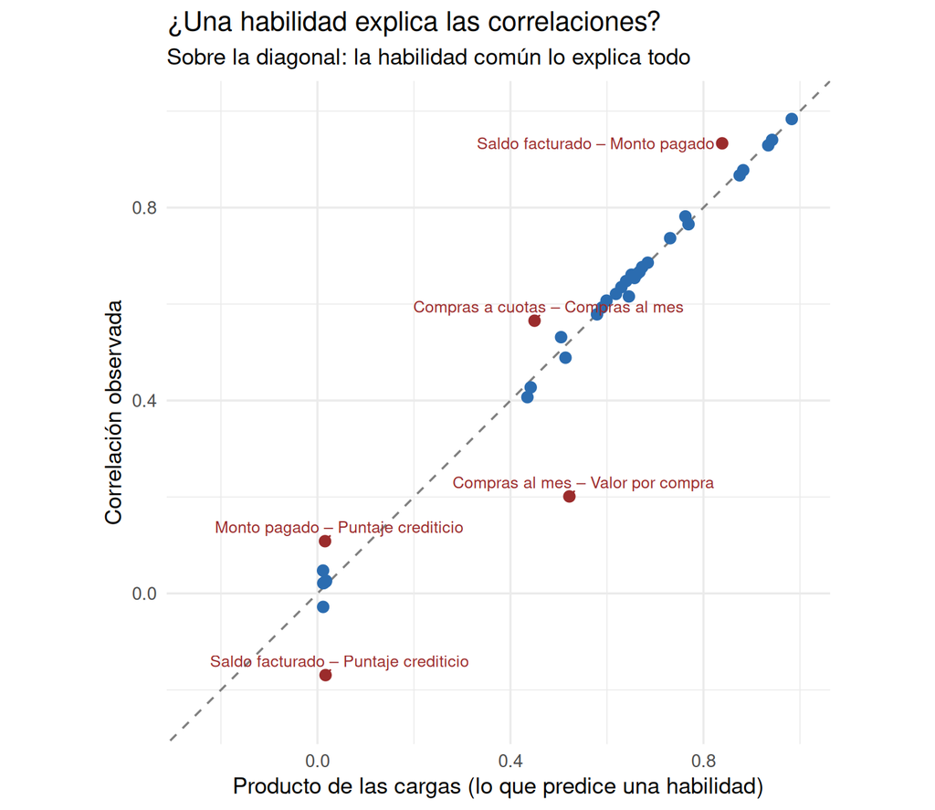

```r
comparacion$par <- paste(comparacion$var_1, "–", comparacion$var_2)
ggplot(comparacion, aes(producto_cargas, correlacion)) +
  geom_abline(slope = 1, intercept = 0, linetype = 2, colour = "grey50") +
  geom_point(aes(colour = abs(diferencia) > 0.08), size = 2.6) +
  geom_text_repel(data = subset(comparacion, abs(diferencia) > 0.08),
                  aes(label = par), size = 3.3, colour = "#9B2C2C", min.segment.length = 0) +
  scale_colour_manual(values = c("FALSE" = "#2B6CB0", "TRUE" = "#9B2C2C"), guide = "none") +
  coord_equal(xlim = c(-0.25, 1), ylim = c(-0.25, 1)) +
  labs(x = "Producto de las cargas (lo que predice una habilidad)",
       y = "Correlación observada",
       title = "¿Una habilidad explica las correlaciones?",
       subtitle = "Sobre la diagonal: la habilidad común lo explica todo")
```

- 👀 **Qué vemos**: 31 de los 36 pares quedan a menos de 0,05 de la diagonal y se apartan 5: el más lejano es **compras al mes – valor por compra** (la habilidad predice 0,52 y la correlación real es 0,20), seguido de **saldo** y **pago** con el **puntaje**, y de cuotas – compras al mes y saldo – pago.
- 💼 **Qué significa para el cliente**: una habilidad reproduce casi toda la ficha, y lo que no explica son dos cosas: **cómo se gasta** (a igual capacidad, muchas compras pequeñas o pocas grandes, la paradoja de Simpson del informe de entrega) y que **el saldo baja el puntaje y el pago lo sube** más de lo que predice la capacidad, que es conducta de pago y no tamaño.
- ✅ **Qué decide el cliente**: una habilidad alcanza para casi toda la ficha pero no para todo, así que vale la pena probar con dos.

# 3 Dos habilidades

```r
fa2 <- fa(R, nfactors = 2, fm = "ml", rotate = "oblimin", n.obs = nrow(X))
L2 <- unclass(fa2$loadings)
# Cuál factor es la capacidad: el que más carga en el cupo. Se pone primero y con signo positivo.
f_cap <- which.max(abs(L2["Cupo", ]))
orden <- c(f_cap, setdiff(1:2, f_cap))
L2 <- L2[, orden]
signo <- c(sign(L2["Cupo", 1]), sign(L2[which.max(abs(L2[, 2])), 2]))
L2 <- sweep(L2, 2, signo, `*`)
colnames(L2) <- c("F1_capacidad", "F2_segundo")
Phi <- fa2$Phi[orden, orden] * outer(signo, signo)

data.frame(variable = rownames(L2), round(L2, 3),
           comun_1_factor = round(100 * carga1^2, 1),
           comun_2_factores = round(100 * fa2$communality, 1),
           row.names = NULL)
```

| variable | F1_capacidad | F2_segundo | comun_1_factor | comun_2_factores |
| --- | --- | --- | --- | --- |
| Ingreso anual | 0.987 | 0.025 | 97.5 | 97.5 |
| Cupo | 0.994 | 0.026 | 99.1 | 98.9 |
| Saldo facturado | 0.952 | -0.170 | 89.6 | 93.7 |
| Monto pagado | 0.891 | 0.107 | 78.5 | 80.4 |
| Compras a cuotas | 0.666 | -0.028 | 44.3 | 44.5 |
| Compras al mes | 0.676 | 0.021 | 45.7 | 45.7 |
| Valor por compra | 0.773 | 0.022 | 59.7 | 59.8 |
| Compras internacionales | 0.652 | 0.047 | 42.7 | 42.7 |
| Puntaje crediticio | 0.003 | 0.998 | 0.0 | 99.5 |

```r
c(correlacion_entre_factores = round(Phi[1, 2], 3))
```

```
## correlacion_entre_factores
##                     -0.003
```

```r
dominante <- rownames(L2)[which.max(abs(L2[, 2]))]
fuertes_F2 <- rownames(L2)[abs(L2[, 2]) > 0.3]
```

```r
# ¿Mejoró la reproducción de las correlaciones?
residuo <- function(modelo) { E <- R - modelo$model; diag(E) <- 0; E }
E1 <- residuo(fa1); E2 <- residuo(fa2)
data.frame(modelo = c("Un factor", "Dos factores"),
           mayor_diferencia = round(c(max(abs(E1)), max(abs(E2))), 3),
           par_mas_lejano = c(paste(rownames(R)[which(abs(E1) == max(abs(E1)), arr.ind = TRUE)[1, ]], collapse = " – "),
                              paste(rownames(R)[which(abs(E2) == max(abs(E2)), arr.ind = TRUE)[1, ]], collapse = " – ")),
           de_cada_100_comun = round(100 * c(sum(fa1$communality), sum(fa2$communality)) / p, 1))
```

| modelo | mayor_diferencia | par_mas_lejano | de_cada_100_comun |
| --- | --- | --- | --- |
| Un factor | 0.321 | Valor por compra – Compras al mes | 61.9 |
| Dos factores | 0.322 | Valor por compra – Compras al mes | 73.6 |

- 👀 **Qué vemos**: la primera habilidad sigue siendo la capacidad, con las mismas cargas, y la segunda carga 0,998 en el **puntaje crediticio** (ninguna otra variable pasa de 0,3); las dos casi no se correlacionan (-0,003) y el par compras al mes – valor por compra sigue sin explicarse.
- 💼 **Qué significa para el cliente**: **la segunda no es una habilidad con sentido, es una sola variable**, el puntaje con otro nombre, y que su parte común pase de 0 a casi 100 solo quiere decir que el modelo le dio un factor para él solo.
- ✅ **Qué decide el cliente**: la respuesta no cambia, una capacidad común y el riesgo aparte, y llamar «riesgo financiero» al segundo factor sería inventar una habilidad donde hay una sola variable.

## 3.1 ¿Y si sacamos el puntaje?

Como el puntaje se queda con el segundo factor, lo sacamos y volvemos a probar con dos, para ver si aparece la segunda cosa que la capacidad no explicaba (cómo se gasta).

```r
R8 <- R[-p, -p]
fa2b <- fa(R8, nfactors = 2, fm = "ml", rotate = "oblimin", n.obs = nrow(X))
L2b <- unclass(fa2b$loadings)
ob <- c(which.max(abs(L2b["Cupo", ])), which.max(abs(L2b["Compras al mes", ])))
sb <- c(sign(L2b["Cupo", ob[1]]), sign(L2b["Compras al mes", ob[2]]))
L2b <- sweep(L2b[, ob], 2, sb, `*`)
colnames(L2b) <- c("F1_capacidad", "F2_frecuencia")
round(L2b, 3)
```

```
##                         F1_capacidad F2_frecuencia
## Ingreso anual                  0.919         0.143
## Cupo                           0.918         0.154
## Saldo facturado                0.873         0.150
## Monto pagado                   0.818         0.141
## Compras a cuotas               0.525         0.269
## Compras al mes                 0.187         0.903
## Valor por compra               0.991        -0.372
## Compras internacionales        0.615         0.076
```

```r
c(correlacion_entre_factores = round(fa2b$Phi[ob[1], ob[2]] * prod(sb), 3))
```

```
## correlacion_entre_factores
##                      0.427
```

- 👀 **Qué vemos**: sin el puntaje, la segunda habilidad carga 0,90 en compras al mes y -0,37 en valor por compra (sube una y baja la otra), y esta vez las dos habilidades **sí se correlacionan** (0,43).
- 💼 **Qué significa para el cliente**: es **frecuencia frente a ticket** (a igual capacidad, hay quien compra mucho y barato y quien compra poco y caro), pero cuelga casi de una variable, así que es una pista y no un hallazgo.
- ✅ **Qué decide el cliente**: la lista de seguimiento no cambia, y la pista le sirve al área comercial para campañas por frecuencia o por ticket.

## 3.2 El factor frente al resumen del PCA

```r
lambda <- eigen(R)$values
data.frame(metodo = c("PCA: primera componente", "Análisis factorial: un factor"),
           de_cada_100 = round(100 * c(lambda[1], sum(fa1$communality)) / p, 1))
```

| metodo | de_cada_100 |
| --- | --- |
| PCA: primera componente | 64.3 |
| Análisis factorial: un factor | 61.9 |

- 👀 **Qué vemos**: la primera componente guarda 64,3 de cada 100 partes de las 9 variables y la habilidad común 61,9.
- 💼 **Qué significa para el cliente**: el PCA busca el resumen que más guarde y por eso se lleva también parte de lo propio de cada variable, mientras que el factor solo cuenta lo compartido y por eso guarda menos.
- ✅ **Qué decide el cliente**: para ordenar la cartera usa el mapa del PCA, y para explicar por qué ingreso, cupo y saldo se mueven juntos usa la capacidad del análisis factorial.

# 4 Preguntas conceptuales

**1. ¿Qué diferencia hay entre la parte común y la parte propia de un módulo?**

La **parte común** es la porción de las diferencias entre personas en ese módulo que viene de la habilidad compartida con los demás módulos: es la carga al cuadrado. La **parte propia** es lo que queda: lo que el módulo mide y ningún otro mide, más su error de medición. Las dos suman 100 de cada 100. En nuestra cartera, el cupo es 99 de cada 100 común (casi todo lo explica la capacidad) y el puntaje es 100 de cada 100 propio (no lo explica en absoluto).

**2. Escritura tiene 15 de cada 100 partes comunes. ¿Significa que el módulo de escritura está mal hecho? ¿Por qué?**

No. Significa que escritura **comparte poco** con los otros módulos, no que mida mal. Los otros 85 pueden ser una habilidad propia de escribir que los demás módulos no miden —información valiosa que solo ese módulo aporta— y solo una parte será error. El análisis factorial no distingue esas dos cosas dentro de la parte propia; para saber si el módulo es confiable habría que medir su fiabilidad por otro camino (por ejemplo, repetir la prueba). Es lo mismo que nuestro puntaje crediticio: 100 de cada 100 propio, y es la variable más útil de la ficha para la Gerencia.

**3. Si la correlación entre dos módulos es casi igual al producto de sus cargas, ¿qué nos dice eso sobre cuántas habilidades hay?**

Que **una habilidad alcanza** para explicar lo que esos dos módulos comparten: se parecen entre sí solo porque los dos se parecen a la misma habilidad, y no queda nada en común entre ellos que necesite una segunda. Si eso pasa con todos los pares, hay una sola habilidad. En nuestra cartera pasa con 31 de 36 pares; los que se apartan (compras al mes – valor por compra, saldo y pago con el puntaje) son los que piden mirar una segunda.

**4. La segunda habilidad cae casi entera sobre lectura. ¿Por qué no la llamamos «habilidad verbal»?**

Porque una habilidad es algo que **comparten varios módulos**, y esta la tiene uno solo. Un factor que carga en una única variable no es una habilidad nueva: es la parte propia de lectura a la que el modelo le dio un factor. Llamarla «verbal» afirmaría que hay una capacidad que también se ve en otros módulos, y los datos no lo muestran. Para llamarla así necesitaríamos al menos dos o tres módulos (por ejemplo, lectura y escritura) cargando fuerte en ella. Es exactamente lo que nos pasó con el puntaje: el segundo factor es el puntaje solo, y por eso no lo llamamos «riesgo financiero».

**5. ¿Por qué el resumen de la sesión 3 guardaba más de cada 100 que la habilidad común de hoy?**

Porque la primera componente principal se construye para **guardar lo máximo posible** de las diferencias totales, sin importar si son comunes o propias: usa también parte de la parte propia de cada variable. La habilidad común solo cuenta lo que las variables **comparten** (la suma de las partes comunes) y deja fuera, por diseño, la parte propia. Por eso el factor siempre guarda menos que la primera componente. En nuestros datos: 64,3 frente a 61,9 de cada 100.

**6. ¿Cuál de estas afirmaciones es correcta?**

La correcta es la **(b)**: *la carga al cuadrado es la parte de las diferencias en un módulo que viene de la habilidad común*. Las otras son falsas:

- **(a)** La habilidad común **no** se mide directamente: es una variable latente que se infiere de lo que los módulos comparten. Nadie le puso a nuestros clientes una nota de «capacidad»; la deducimos de ingreso, cupo, saldo y compras.
- **(c)** La parte propia **no** es siempre error: incluye lo que el módulo mide y los demás no. El puntaje crediticio es 100 % propio y no es error, es otra cosa.
- **(d)** Dos habilidades **no** son siempre independientes: con una rotación oblicua (la que usa `fa()` por defecto) pueden correlacionarse. En nuestros datos, sin el puntaje, capacidad y frecuencia se correlacionan 0,43.

# 5 Lo que le entregamos a la Gerencia

1. **Sí hay una capacidad económica común** detrás de la ficha: explica casi todo del ingreso y el cupo, buena parte del saldo y el pago, y cerca de la mitad de las variables de uso. Reúne 61,9 de cada 100 partes de las 9 variables.
2. **El puntaje crediticio no es parte de esa capacidad**: es 100 % parte propia y su KMO es el más bajo posible. Medir el tamaño de un cliente no dice nada de qué tan buen pagador es.
3. **Una habilidad casi alcanza**: reproduce 31 de las 36 correlaciones. Lo que no explica tiene nombre: cómo se gasta (frecuencia frente a ticket) y la relación del puntaje con el saldo y el pago.
4. **La segunda habilidad no es una habilidad**: es el puntaje solo. La recomendación es la misma de los talleres de PCA, ahora desde otro método: la decisión de seguimiento necesita **dos cosas por separado**, la capacidad (cuánto pesa el cliente) y el puntaje (qué tan riesgoso es).